# Churn on Telcom - Modeling

Rizqi Haryastuti

## Brief Description

Laman ini adalah laman ke-2 (setelah **eksplorasi**), berisi **modeling** mengenai “aktifitas churn” pelanggan sebuah perusahaan telekomunikasi. Studi kasus berikut diberikan pada mata kuliah STK692 (TA 19/20), program studi S2 Statistika Terapan, IPB. Data dan keterangan dapat diakses melalui https://www.stat.ipb.ac.id/pasca/id/index.php/2019/11/19/527/.

Oleh: Muthia Nadhira Faladiba, Citra Komang Sari, Rizqi Haryastuti

Pada pemodelan prediksi dalam studi kasus ini, dicobakan algoritma dasar klasifikasi (*Base Learner*), yakni *random forest*, *boosting*, dan *random undersampling boosting*, serta algoritma yang dapat menggabungkan algoritma dasar (*ensemble*), *Super Learner*.

```r
library(caret)
library(randomForest)
library(rpart)
library(ada)
library(adabag)
library(ebmc)
library(SuperLearner)
library(ranger)
library(xgboost)
library(glmnet)
```

```r
loc <- "D:/RH/2 AKADEMIK S2/Semester 3/STK692 - Studi Kasus/dataexp.csv"
dataexp <- read.csv(loc, header=T)

## arrange data
dataexp[c(17:22)] <- lapply(dataexp[c(17:22)], function(x) as.factor(x))
```

Dilakukan *undersampling* dan *balancing* terhadap 90000 data, yakni masing-masing 4500 untuk pelanggan dengan status “Churn” dan “Stay”.

```r
d1s <- dataexp[which(dataexp$lapsed_flag==0),]
d1c <- dataexp[which(dataexp$lapsed_flag==1),]

set.seed(197)
sampel <- sample(1:nrow(d1c), 4500)

train <- rbind(d1s[sampel,], d1c[sampel,])
test <- rbind(d1s[-sampel,], d1c[-sampel,])
data <- train
```

# Base Learner

## Random Forest

```r
met.RF=function(k.cv, ulang){
  hsl2=NULL
  for (i in 1:ulang){
    acak=createFolds(data$lapsed_flag, k=k.cv)
    hsl1=NULL
    for (j in 1:k.cv){
      training<-data[-(acak[[j]]),-c(2:3,11:13)]
      testing<-data[acak[[j]],-c(2:3,11:13)]

      # Random Forest
      rf<-randomForest(lapsed_flag~., data=training)
      pred.rf<-predict(rf, testing)
      hasil=confusionMatrix(pred.rf, testing$lapsed_flag, positive = '0')
      # Hasil Kebaikan
      acc=hasil$overall[1]
      sen=hasil$byClass[1]
      spe=hasil$byClass[2]
      ratgeo=(acc*sen*spe)^(1/3)
      # Hasil Akhir
      hsl=cbind(acc,sen,spe,ratgeo)
      hsl1=rbind(hsl1, hsl)
    }
    hsl2=rbind(hsl2, hsl1)
  }

  #result
  rownames(hsl2)=c(1:(ulang*k.cv))
  rincian=data.frame(hsl2)
  rataan=cbind.data.frame(mean(hsl2[,1]),mean(hsl2[,2]),mean(hsl2[,3]),mean(hsl2[,4]))
  colnames(rataan)=c('acc','sen','spe','ratgeo')
  result=list('Rincian Random Forest'=rincian,
              'Rataan Random Forest'=rataan)
  return(result)
}
```

```r
hasil.RF.nofull=met.RF(k.cv = 5, ulang = 3)
hasil.RF.nofull
```

```
## $`Rincian Random Forest`
##          acc       sen       spe    ratgeo
## 1  0.7788889 0.7444444 0.8133333 0.7783808
## 2  0.7655556 0.7344444 0.7966667 0.7651339
## 3  0.7372222 0.7000000 0.7744444 0.7365952
## 4  0.7688889 0.7566667 0.7811111 0.7688241
## 5  0.7494444 0.7166667 0.7822222 0.7489663
## 6  0.7605556 0.7366667 0.7844444 0.7603054
## 7  0.7650000 0.7444444 0.7855556 0.7648158
## 8  0.7516667 0.7144444 0.7888889 0.7510518
## 9  0.7594444 0.7388889 0.7800000 0.7592589
## 10 0.7722222 0.7088889 0.8355556 0.7704869
## 11 0.7377778 0.6944444 0.7811111 0.7369284
## 12 0.7544444 0.7211111 0.7877778 0.7539532
## 13 0.7577778 0.7377778 0.7777778 0.7576018
## 14 0.7622222 0.7311111 0.7933333 0.7617987
## 15 0.7605556 0.7300000 0.7911111 0.7601461
##
## $`Rataan Random Forest`
##         acc       sen       spe    ratgeo
## 1 0.7587778 0.7273333 0.7902222 0.7582832
```

## Boosting

```r
met.Boost=function(k.cv, ulang){
  hsl2=NULL
  for (i in 1:ulang){
    acak=createFolds(data$lapsed_flag, k=k.cv)
    hsl1=NULL
    for (j in 1:k.cv){
      training<-data[-(acak[[j]]),-c(2:3,11:13)]
      testing<-data[acak[[j]],-c(2:3,11:13)]

      # Boosting
      boost<-ada(lapsed_flag~., data=training, type="discrete")
      pred.boost<-predict(boost, testing)
      pred.boost<-as.factor(pred.boost)
      hasil=confusionMatrix(pred.boost, as.factor(testing$lapsed_flag), positive = '0')
      # Hasil Kebaikan
      acc=hasil$overall[1]
      sen=hasil$byClass[1]
      spe=hasil$byClass[2]
      ratgeo=(acc*sen*spe)^(1/3)
      # Hasil Akhir
      hsl=cbind(acc,sen,spe,ratgeo)
      hsl1=rbind(hsl1, hsl)
    }
    hsl2=rbind(hsl2, hsl1)
  }

  #result
  rownames(hsl2)=c(1:(ulang*k.cv))
  rincian=data.frame(hsl2)
  rataan=cbind.data.frame(mean(hsl2[,1]),mean(hsl2[,2]),mean(hsl2[,3]),mean(hsl2[,4]))
  colnames(rataan)=c('acc','sen','spe','ratgeo')
  result=list('Rincian Boosting'=rincian,
              'Rataan Boosting'=rataan)
  return(result)
}
```

```r
hasil.Boost.nofull=met.Boost(k.cv = 5, ulang = 3)
hasil.Boost.nofull
```

```
## $`Rincian Boosting`
##          acc       sen       spe    ratgeo
## 1  0.7622222 0.7277778 0.7966667 0.7617030
## 2  0.7372222 0.7144444 0.7600000 0.7369876
## 3  0.7416667 0.7155556 0.7677778 0.7413601
## 4  0.7750000 0.7766667 0.7733333 0.7749988
## 5  0.7733333 0.7444444 0.8022222 0.7729734
## 6  0.7677778 0.7311111 0.8044444 0.7671936
## 7  0.7600000 0.7400000 0.7800000 0.7598245
## 8  0.7572222 0.7444444 0.7700000 0.7571503
## 9  0.7488889 0.7277778 0.7700000 0.7486905
## 10 0.7555556 0.7400000 0.7711111 0.7554488
## 11 0.7466667 0.7266667 0.7666667 0.7464881
## 12 0.7605556 0.7166667 0.8044444 0.7597104
## 13 0.7650000 0.7277778 0.8022222 0.7643958
## 14 0.7611111 0.7566667 0.7655556 0.7611025
## 15 0.7522222 0.7355556 0.7688889 0.7520991
##
## $`Rataan Boosting`
##         acc      sen       spe    ratgeo
## 1 0.7576296 0.735037 0.7802222 0.7573418
```

## RUS Boost

```r
met.RUS.Boost=function(k.cv, ulang){
  hsl2=NULL
  for (i in 1:ulang){
    acak=createFolds(data$lapsed_flag, k=k.cv)
    hsl1=NULL
    for (j in 1:k.cv){
      training<-data[-(acak[[j]]), -c(2:3,11:13)]
      testing<-data[acak[[j]],-c(2:3,11:13)]

      # Boosting
      rus.boost <- rus(lapsed_flag ~ ., data = training, size = 10,
                       alg = "c50", ir = 1)
      pred.rus.boost<-predict(rus.boost, testing, type="class")
      pred.rus.boost<-as.factor(pred.rus.boost)
      hasil=confusionMatrix(pred.rus.boost, as.factor(testing$lapsed_flag), positive = '0')
      # Hasil Kebaikan
      acc=hasil$overall[1]
      sen=hasil$byClass[1]
      spe=hasil$byClass[2]
      ratgeo=(acc*sen*spe)^(1/3)
      # Hasil Akhir
      hsl=cbind(acc,sen,spe,ratgeo)
      hsl1=rbind(hsl1, hsl)
    }
    hsl2=rbind(hsl2, hsl1)
  }

  #result
  rownames(hsl2)=c(1:(ulang*k.cv))
  rincian=data.frame(hsl2)
  rataan=cbind.data.frame(mean(hsl2[,1]),mean(hsl2[,2]),mean(hsl2[,3]),mean(hsl2[,4]))
  colnames(rataan)=c('acc','sen','spe','ratgeo')
  result=list('Rincian RUS-Boost'=rincian,
              'Rataan RUS-Boost'=rataan)
  return(result)
}
```

```r
hasil.RUS.Boost=met.RUS.Boost(k.cv = 5, ulang = 3)
hasil.RUS.Boost
```

```
## $`Rincian RUS-Boost`
##          acc       sen       spe    ratgeo
## 1  0.7266667 0.6733333 0.7800000 0.7253595
## 2  0.7327778 0.6811111 0.7844444 0.7315615
## 3  0.7444444 0.6944444 0.7944444 0.7433234
## 4  0.7211111 0.6766667 0.7655556 0.7201969
## 5  0.7338889 0.6544444 0.8133333 0.7310110
## 6  0.7288889 0.6922222 0.7655556 0.7282735
## 7  0.7455556 0.6955556 0.7955556 0.7444361
## 8  0.7438889 0.6911111 0.7966667 0.7426386
## 9  0.7522222 0.7055556 0.7988889 0.7512559
## 10 0.7238889 0.6577778 0.7900000 0.7218707
## 11 0.7244444 0.6755556 0.7733333 0.7233430
## 12 0.7527778 0.6855556 0.8200000 0.7507715
## 13 0.7411111 0.6788889 0.8033333 0.7393657
## 14 0.7338889 0.6622222 0.8055556 0.7315486
## 15 0.7411111 0.6788889 0.8033333 0.7393657
##
## $`Rataan RUS-Boost`
##         acc       sen       spe    ratgeo
## 1 0.7364444 0.6802222 0.7926667 0.7349548
```

# Super Learner

**recall!**

d1s <- dataexp[which(dataexp$lapsed_flag==0),] d1c <- dataexp[which(dataexp$lapsed_flag==1),]

set.seed(197) sampel <- sample(1:nrow(d1c), 4500)

train <- rbind(d1s[sampel,], d1c[sampel,]) test <- rbind(d1s[-sampel,], d1c[-sampel,]) data <- train

### Split: train & test

```r
acak <- createDataPartition(data$lapsed_flag, p=0.8, list=FALSE)
data.tr <- data[acak,-c(2:3,11:13)]
data.ts <- data[-acak,-c(2:3,11:13)]

y <- as.numeric(data.tr[,12])-1
ytest <- as.numeric(data.ts[,12])-1
x <- data.frame(data.tr[,-12])
xtest <- data.frame(data.ts[,-12])
```

### Tunning parameter

```r
SL.ranger.tune <- function(...){
  SL.ranger(..., num.trees=500, mtry=4)
}
SL.randomforest.tune <- function(...){
  SL.ranger(..., num.trees=500, mtry=4)
}
SL.ipredbagg.tune <- function(...){
  SL.ipredbagg(..., nbagg=250)
}
```

### cross-validation pada Super Learner

```r
cv.model.tune <- CV.SuperLearner(y,
                                 x,
                                 V=5,
                                 SL.library=list("SL.ranger.tune",
                                                 "SL.ipredbagg.tune",
                                                 "SL.xgboost",
                                                 "SL.randomforest.tune"
                                                 ))
```

```r
# Get summary statistics
summary(cv.model.tune)
```

```
##
## Call:
## CV.SuperLearner(Y = y, X = x, V = 5, SL.library = list("SL.ranger.tune",
##     "SL.ipredbagg.tune", "SL.xgboost", "SL.randomforest.tune"))
##
## Risk is based on: Mean Squared Error
##
## All risk estimates are based on V =  5
##
##                 Algorithm     Ave        se     Min     Max
##             Super Learner 0.16599 0.0023356 0.16033 0.17271
##               Discrete SL 0.16719 0.0024205 0.16228 0.17377
##        SL.ranger.tune_All 0.16735 0.0024231 0.16228 0.17461
##     SL.ipredbagg.tune_All 0.17232 0.0023016 0.16456 0.18030
##            SL.xgboost_All 0.18422 0.0029139 0.17768 0.18966
##  SL.randomforest.tune_All 0.16669 0.0024122 0.16160 0.17377
```

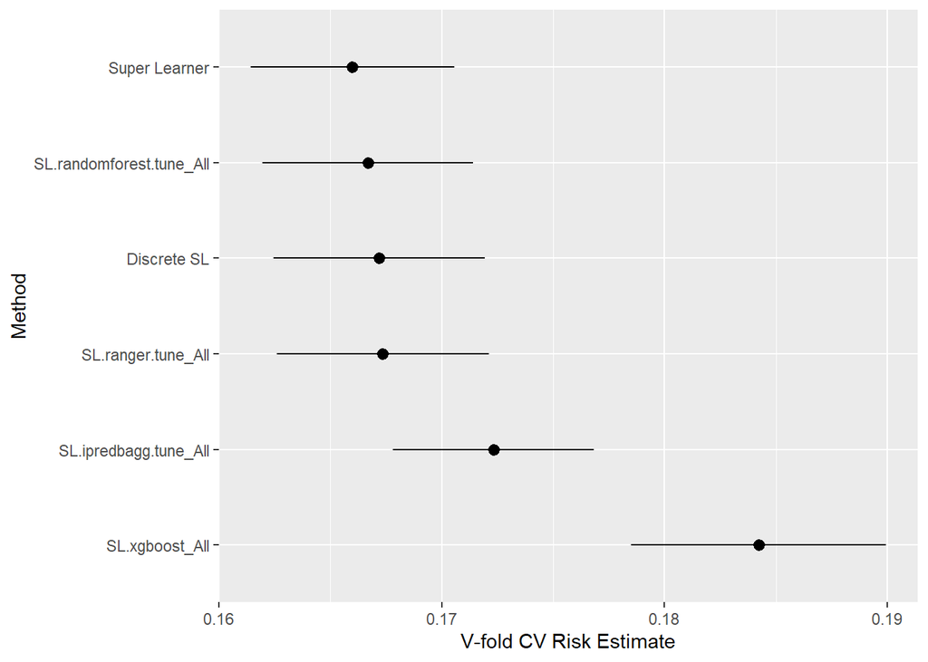

```r
plot(cv.model.tune)
```

```r
# Create the tuned model
model.tune <- SuperLearner(y,
                           x,
                           SL.library=list("SL.ranger.tune",
                                           "SL.ipredbagg.tune",
                                           "SL.xgboost",
                                           "SL.randomforest.tune"
                                           ))
```

Risk yang dihasilkan model dengan metode *random forest* dan *ranger* hampir sama. Hal ini wajar terjadi karena *ranger* merupakan implementasi dari random forest namun dengan komputasi yang lebih cepat (*fast implementation*).

```r
# Gather predictions for the tuned model
predictions.tune <- predict.SuperLearner(model.tune, newdata=xtest)
conv.preds <- ifelse(predictions.tune$library.predict[,4]>=0.5,1,0)
eval.sl <- confusionMatrix(as.factor(conv.preds), as.factor(ytest))
eval.sl
```

```
## Confusion Matrix and Statistics
##
##           Reference
## Prediction   0   1
##          0 652 180
##          1 248 720
##
##                Accuracy : 0.7622
##                  95% CI : (0.7419, 0.7817)
##     No Information Rate : 0.5
##     P-Value [Acc > NIR] : < 2.2e-16
##
##                   Kappa : 0.5244
##
##  Mcnemar's Test P-Value : 0.001201
##
##             Sensitivity : 0.7244
##             Specificity : 0.8000
##          Pos Pred Value : 0.7837
##          Neg Pred Value : 0.7438
##              Prevalence : 0.5000
##          Detection Rate : 0.3622
##    Detection Prevalence : 0.4622
##       Balanced Accuracy : 0.7622
##
##        'Positive' Class : 0
##
```

Berdasarkan pemodelan dengan *Base Learner* dan *Super Learner*, kelompok kami memutuskan model prediksi dengan metode *Random Forest* adalah model yang lebih dibandingkan model dengan metode lain.